# Image Classification (CIFAR 100)

```python
!pip install --quiet keras-tuner tqdm wandb pytz tensorflow-addons glob2 tensorflow==2.10.0
```

> Install a few extra libraries:
> - `keras-tuner`: Hyperparameter optimization framework
> - `tqdm`: Progress bar
> - `wandb`: Explained later
> - `pytz`: For time
> - `tensorflow-addons`: Extention of tensorflow for more advanced implementations
> - `glob`: Pathname pattern recognition
> - `tensorflow_probability`: combine probabilistic models and deep learning on modern hardware

# Objectives & goals for CA1

1. Perform image classification on the CIFAR-100 dataset and obtain a good competitive accuracy score (low avoidable bias), simultaneously searching for a model that does not overfit.
2. Try out different training methodology and experiment with SOTA model architectures, training procedures and data augmentation without hurting the performance of model

# Prediction task and background research

> - **Can we develop a deep learning model to classify images in the CIFAR-100 dataset, particularly using a CNN architecture**
> - **This is a multi-class classification task**

## Imports

```python
import numpy as np
import gc
import pandas as pd
from matplotlib import pyplot as plt
from sklearn.model_selection import train_test_split
from matplotlib.ticker import FormatStrFormatter
import matplotlib
from tqdm import tqdm
import seaborn as sns
import os, time, math, datetime, warnings, pytz, glob
from IPython.display import display
from functools import reduce
from sklearn.metrics import classification_report,accuracy_score, confusion_matrix
warnings.filterwarnings('ignore')

os.environ['TF_CPP_MIN_LOG_LEVEL'] = '2'  # Ignore warnings

%matplotlib inline
```

```python
import absl.logging
absl.logging.set_verbosity(absl.logging.ERROR)
# ignore warning
import logging
logging.getLogger('tensorflow').disabled = True
```

```python
import sys
if 'google.colab'  not in sys.modules:
    os.environ['CUDA_VISIBLE_DEVICES'] = '-1'
```

```python
import tensorflow as tf
# Data source
from tensorflow.keras.datasets import cifar100

from tensorflow.keras.utils import Sequence, to_categorical

# Modelling
from tensorflow.keras import Sequential
from tensorflow.keras.models import Model, load_model
from tensorflow.keras.layers import (Dense, Input, InputLayer, Normalization, Flatten,BatchNormalization,
    Dropout,Conv2D, GlobalAveragePooling2D, MaxPooling2D, ReLU, Layer,Activation, Multiply, AveragePooling2D,
    Add, RandomRotation,Resizing, Rescaling, Reshape, Concatenate, concatenate, Lambda, add, GlobalMaxPooling2D)

from tensorflow.keras import layers as L
from tensorflow.keras import backend as K

from tensorflow.keras.utils import to_categorical, plot_model
from tensorflow.keras.callbacks import EarlyStopping, ModelCheckpoint, LearningRateScheduler, ReduceLROnPlateau, TerminateOnNaN, TensorBoard, CSVLogger, Callback
from tensorflow.keras.backend import clear_session
from tensorflow.keras.optimizers import RMSprop, SGD, Adam, Adagrad, Adamax


from tensorflow.keras.optimizers.schedules import *
from tensorflow.keras.metrics import FalseNegatives, categorical_crossentropy, sparse_categorical_crossentropy
from tensorflow.keras.regularizers import l2, L2
from tensorflow.keras.losses import CategoricalCrossentropy
from tensorflow.keras.preprocessing.image import ImageDataGenerator
from tensorflow.image import random_flip_left_right, resize_with_crop_or_pad, random_crop
# from tensorflow.keras import mixed_precision
# mixed_precision.set_global_policy('mixed_float16')
print('TensorFlow Version:', tf.__version__)

# TFA
from tensorflow_addons.optimizers import SWA


from kerastuner.tuners import Hyperband
from kerastuner import HyperModel
# from keras_adabound import AdaBound
```

```
TensorFlow Version: 2.10.0
```

```python
seed = 42
tf.random.set_seed(seed)
np.random.seed(seed)
# random seed for reproducibility
```

### Weights & Biases

- A MLOps platform with a novelty feature of experiment tracking to see machine learning model's performances of different versionings.
- Build better models faster with experiment tracking, dataset versioning, and model management

```python
import wandb
from wandb.keras import WandbCallback
```

```python
wandb.login()
# paste this pls e6ba4b45952ca612073be61bfda87ceca39072c5
```

```
Failed to detect the name of this notebook, you can set it manually with the WANDB_NOTEBOOK_NAME environment variable to enable code saving.
wandb: Currently logged in as: lhurr. Use `wandb login --relogin` to force relogin
```

```
True
```

### Check GPU

```python
print("Num GPUs Available: ", len(tf.config.list_physical_devices('GPU')))
print(tf.__version__)
print(tf.config.list_physical_devices('GPU'))
```

```
Num GPUs Available:  0
2.10.0
[]
```

### Reading dataset

1. We load the data using `load_data` and it returns 2 tuples for us
2. For the purpose of training and evaluating the model, we need to have our data in the form of 3 sets: `train`, `validation` and `test`. Ideally, the training data is used to train the model, validation data is used to perform tuning of models, and the test data will act as a final independant evaluation of the performance of the final model and its ability to generalize well.(low variance)
3. Furthermore, the model's performance can also be evaluated on the validation data on each epoch of training.
4. Hence, we will perform a 20% split on the train set (.8) to allocate 10000 images for the validation set (.2).
5. Since CIFAR100 dataset is not extremely large (not millions of records), i felt that a 20% split would be relevant. furthermore, we are also making decisions based on validation set. Hence, we must try to avoid overfitting the validation set.
- X_train: 40000
- X_val: 10000
- X_test: 10000

```python
(X_train_orig, y_train_orig), (X_test, y_test) = cifar100.load_data()
IMG_SIZE = (32,32,3)
# third axis is the RGB channel
```

```python
X_train, y_train, X_val, y_val = X_train_orig[:40000], y_train_orig[:40000], X_train_orig[40000:], y_train_orig[40000:]
```

```python
# credits: https://huggingface.co/datasets/cifar100
NUM_CLASSES = 100
LABELS = {
0: 'apple',1: 'aquarium_fish',2: 'baby',3: 'bear',4: 'beaver',5: 'bed',6: 'bee',7: 'beetle',8: 'bicycle',9: 'bottle',10: 'bowl',
11: 'boy',12: 'bridge',13: 'bus',14: 'butterfly',15: 'camel',16: 'can',17: 'castle',18: 'caterpillar',19: 'cattle',20: 'chair',
21: 'chimpanzee',22: 'clock',23: 'cloud',24: 'cockroach',25: 'couch',26: 'cra',27: 'crocodile',28: 'cup',29: 'dinosaur',30: 'dolphin',31: 'elephant',
32: 'flatfish',33: 'forest',34: 'fox',35: 'girl',36: 'hamster',37: 'house',38: 'kangaroo',39: 'keyboard',40: 'lamp',41: 'lawn_mower',42: 'leopard',
43: 'lion',44: 'lizard',45: 'lobster',46: 'man',47: 'maple_tree',48: 'motorcycle',49: 'mountain',50: 'mouse',51: 'mushroom',52: 'oak_tree',53: 'orange',
54: 'orchid',55: 'otter',56: 'palm_tree',57: 'pear',58: 'pickup_truck',59: 'pine_tree',60: 'plain',61: 'plate',
62: 'poppy',63: 'porcupine',64: 'possum',65: 'rabbit',66: 'raccoon',67: 'ray',68: 'road',69: 'rocket',70: 'rose',71: 'sea',
72: 'seal',73: 'shark',74: 'shrew',75: 'skunk',76: 'skyscraper',77: 'snail',78: 'snake',79: 'spider',80: 'squirrel',81: 'streetcar',
82: 'sunflower',83: 'sweet_pepper',84: 'table',85: 'tank',86: 'telephone',87: 'television',88: 'tiger',89: 'tractor',90: 'train',
91: 'trout',92: 'tulip',93: 'turtle',94: 'wardrobe',95: 'whale',96: 'willow_tree',97: 'wolf',98: 'woman',99: 'worm'
}
```

# Preprocessing

- Before we feed data into models, we need to perform preprocessing.

> **Pixel rescaling**
> - Initially, the pixel values for each image in dataset are between 0 and 255.
> - We need to rescale the pixel values to the range of 0 and 1. This is to handle the strong influence very large or small pixel values may pose. For example, if we do not scale, the network learns weights from features that are from different scales, and the large feature may 'drown' out the small features. Not rescaling the pixels can introduce the problem of exploding gradients, due to the high range of pixels.
> - We will divide the pixel values by the maximum value of 255.
> - This was a crucial step as it would improve optimization (faster) and especially critical for optimizers such as SGD, where it converges better and faster when pixel scales are similar. **One hot encoding for target labels**
> - We will also one hot encode the target variable y from the label encoded format

```python
def preprocess(X,y):
    return X/255. , to_categorical(y, num_classes=NUM_CLASSES)

X_train, y_train = preprocess(X_train, y_train)
X_test, y_test = preprocess(X_test, y_test)
X_val , y_val = preprocess(X_val, y_val)
X_train_orig, y_train_orig = preprocess(X_train_orig, y_train_orig)
```

```python
y_train
```

```
array([[0., 0., 0., ..., 0., 0., 0.],
       [0., 0., 0., ..., 0., 0., 0.],
       [1., 0., 0., ..., 0., 0., 0.],
       ...,
       [0., 0., 0., ..., 0., 0., 0.],
       [0., 0., 0., ..., 0., 0., 0.],
       [0., 0., 0., ..., 0., 0., 0.]], dtype=float32)
```

# Modelling

### Evaluation metrics & optimization techniques

- We need to select our metrics/loss (to be optimized) along with our optimization techniques to sepcify under the `.compile()` method later.
- Optimization algorithms aims to minimize cost function, which is difference between the predicted data and the actual values

> **Metrics: Categorical accuracy**
> 1. Since this is a multi-class classification task, and given the fact we have one-hot encoded our `y` labels, `categorical_accuracy` will be used to evaluate the model's performance. However, if we choose to specify `accuracy`, it will not matter as Keras uses `categorical_accuracy` internally for multi-class classification. [Src](https://github.com/keras-team/keras/blob/master/keras/engine/training.py).

> **Loss function: Categorical cross entropy**
> 1. As our prediction task is multi-class classification, we need to use `categorical cross entropy` as our loss function. We will not use `sparse_categorical_crossentropy` as we have one hot encoded the y labels. This loss can be used to measure the difference between two probability distributions. $$Loss = -\frac{1}{N} \sum^N_{i=1}{[y_{i}log(\hat{y}_i) + (1 - y_i) ⋅ log(1 - \hat{y}_i)]}$$ $$\text{where $y_{i}$ is i'th true label, while $\hat{y}_i$ is i'th predicted label }$$

> **Optimizer: SGD with Nesterov Momentum vs Adaptive methods (like adam)**
> - Prior to modelling, we have to carefully select the optimization algorithm, particularly we want a optimizer that can enable the model to generalize well, with low variance, while simultaneously having low avoidable bias. I have shortlisted 2 optimization methods particular SGD or Adam (adaptive method)
> - After research, it was found that [adaptive optimization methods such as Adam have been proven to discover solutions that generalize poorly compared to Stochastic gradient descent](https://arxiv.org/pdf/1712.07628.pdf) [4], these methods tend to perform well on early stages but SGD then outperforms further into training. [It was also shown that the lack of generalization in performance of adaptive methods come from the non-uniform scaling of the gradient](https://arxiv.org/pdf/1705.08292.pdf) [5]. From another study of gradient noise, it was discovered that SGD is more locally unstable than Adam at sharp minimas, and can better [escape from them and converge to minima at the flat or asymmetric basins/valleys, which often have better generalization performance over sharp minimas. Hence, this highlights how SGD is able to generalize better as compared to adam](https://proceedings.neurips.cc/paper/2020/file/f3f27a324736617f20abbf2ffd806f6d-Paper.pdf) [7]. It was further noted that although adaptive methods yielded better training performance, it was not able to generalize as well as SGD, as shown in poor performance in benchmark dev and test set. [5]
> - Despite attempts to improve the generalization performance of Adam, such as introducing [ND ADAM](https://arxiv.org/abs/1709.04546) [6], which preserves gradient direction. However this improvement sacrifises the rapid initial speed of adam. Hence, there is still a gap between SGD and adaptive methods when it comes of generalization ability when it comes to image classification, with SGD being more reliable. However, one thing to note is that Adam has faster convergeance over SGD over lesser epochs. However, since we want our model to be robust, I choose to go with SGD with nesterov momentum **first**, and decide if we need to change it. **We will proceed with SGD first**

> **Activation Functions:**
> - Most of the time, we will be using a rectified linear unit activation function, so as to capture non linearities in the feature map.
> - I did not want to have many sigmoid activation function, as extreme values snap to 1 or -1, this would be challenging for the learning algorithm to continue and update the weights to improve the model.
> - RELU on the other hand, is more robust and is able to handle the problem of vanishing gradients, where the gradient diminishes as it is propagated through the network
> - Softmax: We will use softmax function usually for the last layer for the model to indicate to us the probability of the output class of being true. Softmax will also be used since this is a multi class classification problem

**References:**

- [4] https://arxiv.org/pdf/1712.07628.pdf
- [5] https://arxiv.org/pdf/1705.08292.pdf
- [6] https://arxiv.org/abs/1709.04546
- [7] https://proceedings.neurips.cc/paper/2020/file/f3f27a324736617f20abbf2ffd806f6d-Paper.pdf

**Optimization Hyperparameters**

> **Initial Learning rate**
> - The initial learning rate will be set to 0.5, this is consistent with the implementation details of [Deep Pyramidal networks paper](https://arxiv.org/pdf/1610.02915.pdf) for this task (`The initial learning rate is set to 0.5 for CIFAR-100`). [9] I chose to follow their implementation as it was found to be compatible with pyramid nets, together with my fears that a very small learning rate however may lead to slow convergence. **However, I may change the learning rate later for certain CNN architectures.**

> **Momentum**
> - Momentum helps to speed up gradient descent and minimize oscillations, reducing fluctuations while approaching the optimal solution, which improves efficiency and speed of convergence. More specifically, momentum helps parameter vector to build up velocity in any direction with gradient descent.
> - We will be using a series of models such as pyramid net later on, and it was found that momentum of 0.9 worked well in the [Deep pyramidal networks implementation](https://arxiv.org/pdf/1610.02915.pdf) [9]. Furthermore, this value is quite popular among State of the art CNN architectures such as [Densely connected CNN](https://arxiv.org/pdf/1608.06993.pdf) [10] and WideResNets [8] and even Residual networks [13]. I decided to follow this value.

[figure not shown]

> Source: https://iopscience.iop.org/article/10.1088/1742-6596/1229/1/012046/pdf

# Reduce Learning rate on plateau

- I decided to follow the pyramidal residual networks paper authors' implementation to decay learning rate after some time. However, the main difference between my implementation and theirs is i reduce my learning rate when a particular metric has stopped improving. On the other hand, their implementation reduces the learning rate after a certain epoch.
- The reason why I made this choice is becuase of the following:
  - If i were to keep to a specific learning rate until a certain epoch, I have fears that the model will reach a plateau and metrics does not improve before arriving at that certain epoch. Hence, I wanted a dynamic learning rate that changes based on the performance of the metric of my choice.
  - Therefore, I used ReduceLROnPlateau, to counter the problem of plateaus which slows down the neural network training. The idea behind implementing this is as follows: we want to select an initial learning rate to quickly approach minima, and we want to reduce the learning rate when the validation accuracy stumbles upon plateaus. Hence, to further update the parameters, we need to reduce the learning rate. The purpose of this callback is to decrease the learning rate to allow us to descend into the minimum/ optimal solution, instead of jumping back and fourth far above the optimal solution.
  - I decided to set the factor of which the learning rate will be reduced to be 0.35, while keeping a lower patience. Personally, I wanted the model to have a taste of a variety of learning rates (reduce LR many times, but reduction is less each time), so to thoroughly explore the loss function space. Lowering the `factor` of learning rate would mean that we would reduce the learning rate by a larger multiplier, which means that the learning rate will shrink much faster, and we may face the problem of stagnant weight updates much earlier

```python
reduce_lr = ReduceLROnPlateau(monitor='val_categorical_accuracy',factor=0.35, patience=8,verbose=1)
```

```python
LEARNING_RATE = 0.5
MOMENTUM = 0.9
NESTEROV = True

optimizer = SGD(learning_rate = LEARNING_RATE,momentum = MOMENTUM, nesterov = NESTEROV)
#  reducelr_factor=0.35,reducelr_patience=8, reducelr_min_lr=0
COMPILE_CONFIG = dict(optimizer = optimizer, loss='categorical_crossentropy', metrics=['categorical_accuracy'])
```

# **Starting Model Hyperparameters**

> **Batch size**
> - For batch sizes, there was [sufficient evidence provided by Nitish, et al.](https://arxiv.org/abs/1609.04836) [11], that indicated that a larger batch would result in degradation in the quality of the model, affecting the ability to generalize. This is due to the fact that large batch methods tend to converge to sharp minimizers, leading to high variance issues. [11] To play my cards safe, i pick a batch size of `128`, this also requires less memory. Furthermore, noise gradient updates as a result of lower batch size can help model reach lower error, resulting in a regularizing effect, increasing the robustness of the model.

> **Epochs**
> - I decided to set my epochs to 100, i felt this was an optimal number, we can compensate the training epochs with data augmentation to prevent overfitting.

> **L2 Regularization parameter**
> 1. I decided to set weight decay to 0.0005 (l2 reg param).

[11] https://arxiv.org/abs/1609.04836 [12] https://arxiv.org/pdf/1608.03983.pdf

```python
BATCHSIZE=128
EPOCHS = 100
STEPS_PER_EPOCH = len(X_train) // BATCHSIZE
WEIGHT_DECAY = 0.0005
```

```python
def plot_loss_acc_graph(result):
    epochs = list(range(1, len(result['loss']) + 1))
    sns.set()
    fig, (ax1, ax2) = plt.subplots(1, 2, figsize=(20, 9))
    ax1.plot(epochs,result['loss'], label='Training Loss', marker='o',)
    ax1.plot(epochs,result['val_loss'], label='Validation Loss', marker='o',)
    ax1.set_title('Training and Validation Loss')
    ax1.set_xlabel('Epochs')
    ax1.set_ylabel('Loss')
    ax1.locator_params(integer=True)

    ax1.legend()

    ax2.plot(epochs,result['categorical_accuracy'], label='Training Accuracy', marker='o',)
    ax2.plot(epochs, result['val_categorical_accuracy'], label='Validation Accuracy', marker='o',)
    ax2.set_title('Training and Validation Accuracy')
    ax2.set_xlabel('Epochs')
    ax2.set_ylabel('Accuracy')
    ax2.locator_params(integer=True)

    ax2.legend()
    return fig
```

```python
class EvaluatorHistory:
    def __init__(self) -> None:
        self.history = []
    def evaluate_model(self,model:Model,train_ds,batch_size, val_ds,compile_config,wandb_run, epochs=EPOCHS, monitor = 'val_categorical_accuracy', plot=True, additional_cb = None, augmentation = False):
        """
        Takes in uncompiled model and compile and train it
        """
        K.clear_session()
        model = self.compile_model(model, **compile_config)
        d= dict()
        self.model_name = '{}'.format(model.name)
        self.model_path = 'models/{}/'.format(self.model_name)
        if not os.path.exists(self.model_path):
          os.makedirs(self.model_path)
        self.model_logs = os.path.join(self.model_path, 'training.csv')
        # Check if we have trained the model before, if yes print out the logs (to save time)
        try:
            self.get_logs(self.model_name)
            # print(self.model_logs)
            history = pd.read_csv('{}'.format(self.model_logs))
            fig = plot_loss_acc_graph(history)
            fig.show()
            return
        except Exception as e:
            pass

        self.model_weights = os.path.join(wandb_run.dir,'model-best.h5' )

        self.training_log = os.path.join(wandb_run.dir, 'output.log')
        cb = [CSVLogger(self.model_logs,append=False),
                    TerminateOnNaN(), reduce_lr ]


        # ==================================================================================================

        if additional_cb is not None:
            cb+=additional_cb
        try:
            if augmentation:
                results = model.fit(train_ds,validation_data=val_ds, epochs=epochs, callbacks=cb,batch_size=batch_size)
            else:
                X_train, y_train = train_ds
                results = model.fit(X_train, y_train, epochs=epochs, validation_data=val_ds, batch_size=batch_size, callbacks=cb)
            history = results.history
        except KeyboardInterrupt:
            history = pd.read_csv('{}'.format(self.model_logs))
        wandb_run.finish()
        if plot:
            fig = plot_loss_acc_graph(history)
            fig.show()
        d['Model Name'] = self.model_name
        d['Model Logs'] = self.model_logs
        d['Epoch'] = len(history["loss"])
        d['Model Weights/Model'] = self.model_weights
        best_idx = np.argmax(history['val_categorical_accuracy'])
        d["Train Loss"] = history["loss"][best_idx]
        d["Val Loss"] = history["val_loss"][best_idx]
        d["Train Accuracy"] = history["categorical_accuracy"][best_idx]
        d["Val Accuracy"] = history['val_categorical_accuracy'][best_idx]
        d['Training Log Info'] = self.training_log
        K.clear_session()
        self.history.append(pd.Series(d))
        self.save_history()
        return pd.Series(d).to_frame().T.set_index('Model Name')

    def compile_model(self,model:Model, optimizer, loss, metrics):
        # Compiles a model
        model.compile(optimizer=optimizer, loss=loss, metrics = metrics)
        return model
    def get_model(self, model_name:str, model):
        models_df = self.get_history()
        compiled_model = self.compile_model(model, **COMPILE_CONFIG)
        try:
            compiled_model.load_weights(models_df.loc[models_df['Model Name'] == model_name, 'Model Weights/Model'].item())
        except:
            compiled_model.load_weights(r''.format(models_df.loc[models_df['Model Name'] == model_name, 'Model Weights/Model'].item()))
        return compiled_model
    def get_logs(self, model_name:str):
        """
        Get model logs if it has been recorded before in self.history
        """
        models_df = self.get_history()
        try:
            file_loc = str(models_df.loc[models_df['Model Name'] == model_name, 'Training Log Info'].item())
            # print(file_loc)
            with open(file_loc, 'r') as f:
                print("".join(line for line in f if not line.isspace()))
            # return
        except:
            file_loc = str(models_df.loc[models_df['Model Name'] == model_name, 'Training Log Info'].item())
            # print(file_loc)
            with open(r''.format(file_loc), 'r') as f:
                print("".join(line for line in f if not line.isspace()))
        return

    def save_history(self):
        if not os.path.exists('archive'):
          os.makedirs('archive')
        pd.DataFrame(self.history).to_csv(f'archive/{self.model_name}.csv', index=False, mode= 'w+')
    def get_history(self, strc='BottleNeck'):
        try:
            df = pd.concat([pd.read_csv(f) for f in glob.glob('archive/'+'*{}*.csv'.format(strc))])
            # self.history.append(df)
            return df.drop(columns='Model Logs')
        except:
            pass
```

```python
eval_history = EvaluatorHistory()
```

# PyramidNet

- Pyramid nets act as an improvement based on [residual networks](https://arxiv.org/pdf/1512.03385.pdf) and the pre-activation res nets. It is found that by gradually increasing the feature map dimensions, instead of doubling the filters every set number of residual blocks which is often done. This results in the improvement of classification accuracy, and greater generalization ability [14].
- In CNN architectures, feature map dimensions are not increased unless downsampling occurs. Hence, pyramid net seeks to address this by increasing the feature map dimensions gradually. In this implementation, we will be using the additive pyramid net, which is tested to be better than the multiplicative counterpart

[figure not shown]

> **Specific network configurations**
> - Furthermore, we will be using the pyramid bottleneck architecture, which gradually increases feature map dimensions. However, to match the increasing feature map dimensions of input and output, we perform zero pad identity mapping short cut connection, which was found to be generally better than other shortcut connections. This can be seen from [Deep Pyramidal Residual Networks](https://arxiv.org/pdf/1610.02915.pdf) [14], where they compared zero padded short cut connections with project connections. It was discovered that project shortcut connections yielded poor performance for deep neural networks with many residual units as compared to zero padded shortcut during their testings. [14]
> - Next, I also decided to follow the original authors recommendation to remove the first RELU, and placing a batch norm layer after the final convolution layer for the pyramidNet bottleneck architecture. Both of these changes were found to enhance performance.

> **L2 Regularization**
- Next, I also added l2 regularization to prevent overfitting, l2 reg penalises the model as it gets more complex. It updates the loss function to penalize the model in proportion to the size of weights. This has a regularizing effect, as larger weights result in a more complex and less stable model, whereas smaller weights would reduce the power of hidden neurons, where it would result in a less complex model, therefore the model is less likely to overfit as a result of noise in data. This l2 regularization implementation is consistent with what is done in the pyramidNet paper.

> **Motivation**
- I decided to go with PyramidNet due to its lower parameter count despite of its depth due to the fact that the feature map gradually increases.

[13] [Source](https://sh-tsang.medium.com/review-pyramidnet-deep-pyramidal-residual-networks-image-classification-85a87b60ae78) [14][Deep Pnet](https://arxiv.org/pdf/1610.02915.pdf)

```python
def get_conv(**kwargs):
    return Conv2D(**kwargs)
```

```python
class BottleNeckBlock(Model):
    def __init__(self, no_filters  ,stride, pool = False):
        super(BottleNeckBlock, self).__init__()
        self.downsample = pool
        # self.maxpooling = MaxPooling2D(pool_size=(stride, stride), strides=(stride, stride), padding='valid')

        self.bn0 = BatchNormalization()

        self.conv1 = get_conv(filters = no_filters, kernel_size=1, strides=1, padding='valid' , use_bias = False, kernel_regularizer = L2(WEIGHT_DECAY))
        self.bn1 = BatchNormalization()
        self.act1 = Activation('relu')

        self.conv2 = get_conv(filters = no_filters, kernel_size=3, strides=stride, padding='same' , use_bias = False, kernel_regularizer = L2(WEIGHT_DECAY))
        self.bn2 = BatchNormalization()
        self.act2 = Activation('relu')


        self.conv3 = get_conv(filters = no_filters*4, kernel_size=1, strides=1, padding='valid', use_bias = False, kernel_regularizer = L2(WEIGHT_DECAY))
        self.bn3 = BatchNormalization()
        # self.shake = shakedrop
        self.add = Add()
    def call(self, x):
        out = self.bn0(x)

        out = self.conv1(out)
        out = self.bn1(out)
        out = self.act1(out)

        out = self.conv2(out)
        out = self.bn2(out)
        out = self.act2(out)

        out = self.conv3(out)
        out = self.bn3(out)
        # Found to improve performance with bn after last conv

        shortcut = MaxPooling2D((2,2) , strides = (2,2))(x) if self.downsample else x

        if K.int_shape(shortcut)[3] != K.int_shape(out)[3]:
            shortcut = tf.pad(shortcut, tf.constant( [[0,0] , [0,0] , [0,0] , [0 ,    K.int_shape(out)[3] -  K.int_shape(shortcut)[3] ]] ))


        return self.add([out + shortcut])
```

```python
class PyramidNet(Model):
    def __init__(self  , alpha , N , block = BottleNeckBlock):
        super().__init__()
        n = (N-2)//9
        self.increment = alpha / (n*3.0)
        self.totallayer = n*3.0
        self.block = block
        self.n_layers = 1

        self.conv1 = Conv2D(16 ,3,1,'same'  , use_bias = False )
        self.batchnorm1 = BatchNormalization()
        self.no_filters = 16


        self.group1 = self.group_init(n  , 1  )
        self.group2 = self.group_init(n, 2  )
        self.group3 = self.group_init(n  , 2 )


        self.batchnorm2 = BatchNormalization()
        self.activation = Activation('relu')


        self.avgpool = GlobalAveragePooling2D()


        self.out = Dense(100 , activation = 'softmax' , dtype = 'float32')
    def group_init(self, no_layers,stride  ):
        tempmodel = []
        self.no_filters += self.increment

        tempmodel.append(self.block(int(round(self.no_filters) ), stride , pool = (stride != 1) ) )
        self.n_layers +=1
        for _ in range(no_layers -1 ):
            self.no_filters += self.increment
            tempmodel.append(self.block(int(round(self.no_filters)), stride = 1 , pool = False ,  )  )
            self.n_layers +=1
        return tempmodel

    def call(self , x):
        x = self.conv1(x)
        x = self.batchnorm1(x)
        for layer in self.group1:
            x = layer(x)
        for i,layer in enumerate(self.group2):
            x = layer(x)
        for layer in self.group3:
            x = layer(x)


        x = self.batchnorm2(x)
        x = self.activation(x)
        x = self.avgpool(x)
        x = self.out(x)
        return x
```

```python
p_net = PyramidNet(alpha = 84, N = 164, block=BottleNeckBlock)

inp = Input(shape=(32, 32, 3))
pyramid_bottleneck = Model(inputs=[inp], outputs=p_net.call(inp), name="BottleNeck_PyramidNet")
```

```python
pyramid_bottleneck.summary()
```

```
Model: "BottleNeck_PyramidNet"
_________________________________________________________________
 Layer (type)                Output Shape              Param #
=================================================================
 input_1 (InputLayer)        [(None, 32, 32, 3)]       0

 conv2d (Conv2D)             (None, 32, 32, 16)        432

 batch_normalization (BatchN  (None, 32, 32, 16)       64
 ormalization)

 bottle_neck_block (BottleNe  (None, 32, 32, 72)       4996
 ckBlock)

 bottle_neck_block_1 (Bottle  (None, 32, 32, 76)       6805
 NeckBlock)

 bottle_neck_block_2 (Bottle  (None, 32, 32, 84)       8137
 NeckBlock)

 bottle_neck_block_3 (Bottle  (None, 32, 32, 88)       9004
 NeckBlock)

 bottle_neck_block_4 (Bottle  (None, 32, 32, 96)       10528
 NeckBlock)

 bottle_neck_block_5 (Bottle  (None, 32, 32, 100)      11509
 NeckBlock)

 bottle_neck_block_6 (Bottle  (None, 32, 32, 108)      13225
 NeckBlock)

 bottle_neck_block_7 (Bottle  (None, 32, 32, 112)      14320
 NeckBlock)

 bottle_neck_block_8 (Bottle  (None, 32, 32, 120)      16228
 NeckBlock)

 bottle_neck_block_9 (Bottle  (None, 32, 32, 128)      18400
 NeckBlock)
```

[output cut: 133 more lines]

```
 batch_normalization_217 (Ba  (None, 8, 8, 400)        1600
 tchNormalization)

 activation_108 (Activation)  (None, 8, 8, 400)        0

 global_average_pooling2d (G  (None, 400)              0
 lobalAveragePooling2D)

 dense (Dense)               (None, 100)               40100

=================================================================
Total params: 3,857,128
Trainable params: 3,793,584
Non-trainable params: 63,544
_________________________________________________________________
```

### BottleNeck pyramidal network training

```python
current_time = datetime.datetime.now(pytz.timezone("Singapore")).strftime("%d:%m:%Y_%H:%M")
p_run = wandb.init(
    project="CIFAR-100 Image classification",
    name=f"BottleNeck_PyramidNet{[current_time]}",
    group="BottleNeck_PyramidNet",
    dir=os.getcwd()
)
```

wandb version 0.13.5 is available! To upgrade, please run: $ pip install wandb --upgrade

Tracking run with wandb version 0.13.4

Run data is saved locally in `c:\Users\limhu\Desktop\DELE\CIFAR100\wandb\run-20221121_201636-22ahly99`

Syncing run **[BottleNeck_PyramidNet['21:11:2022_20:16']](https://wandb.ai/lhurr/CIFAR-100%20Image%20classification/runs/22ahly99)** to [Weights & Biases](https://wandb.ai/lhurr/CIFAR-100%20Image%20classification) ([docs](https://wandb.me/run))

- Start run with early stopping:10

```
Epoch 20: ReduceLROnPlateau reducing learning rate to 0.175.
Epoch 34: ReduceLROnPlateau reducing learning rate to 0.06124999895691871.
Epoch 43: ReduceLROnPlateau reducing learning rate to 0.021437499113380908.
Epoch 55: early stopping
```

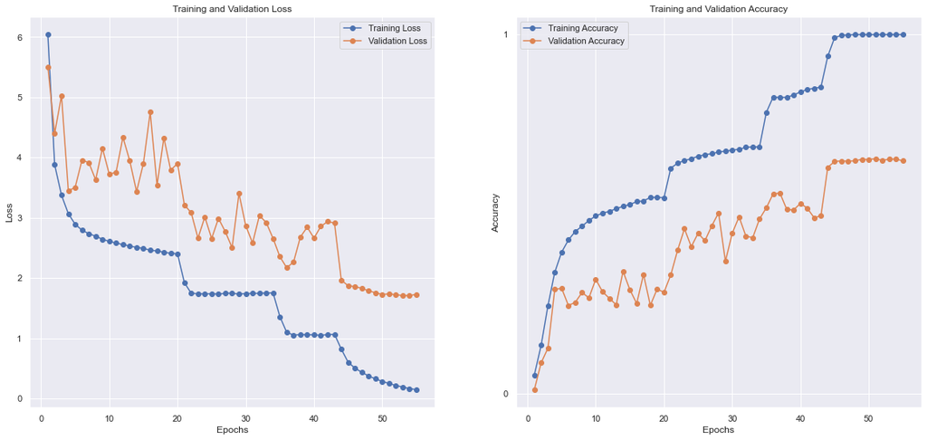

```python
_ = eval_history.evaluate_model(pyramid_bottleneck,(X_train,y_train), BATCHSIZE,val_ds=(X_val, y_val),
compile_config = COMPILE_CONFIG,wandb_run=p_run, epochs=EPOCHS,
additional_cb= [
WandbCallback(monitor="val_categorical_accuracy",save_model=True, save_weights_only=False),
EarlyStopping(monitor='val_categorical_accuracy',
                                patience=10,
                                verbose=1,restore_best_weights=True)],
augmentation=False)
```

```python
display(eval_history.get_history('BottleNeck_PyramidNet').iloc[[0]])
display(eval_history.get_history('Baseline'))
```

|  | Model Name | Epoch | Model Weights/Model | Train Loss | Val Loss | Train Accuracy | Val Accuracy | Training Log Info |
| --- | --- | --- | --- | --- | --- | --- | --- | --- |
| 0 | BottleNeck_PyramidNet | 55 | C:\Users\limhu\Desktop\DELE\CIFAR100\wandb\run... | 0.2519 | 1.737 | 0.9997 | 0.6539 | C:\Users\limhu\Desktop\DELE\CIFAR100\wandb\run... |

|  | Model Name | Epoch | Model Weights/Model | Train Loss | Val Loss | Train Accuracy | Val Accuracy | Training Log Info |
| --- | --- | --- | --- | --- | --- | --- | --- | --- |
| 0 | Baseline_ConvNN | 20 | c:\Users\limhu\Desktop\DELE\CIFAR100\wandb\run... | 1.337099 | 3.271009 | 0.633175 | 0.3232 | c:\Users\limhu\Desktop\DELE\CIFAR100\wandb\run... |
| 0 | Baseline_DataAug | 50 | C:\Users\limhu\Desktop\DELE\CIFAR100\wandb\run... | 2.267077 | 2.329021 | 0.415900 | 0.4145 | C:\Users\limhu\Desktop\DELE\CIFAR100\wandb\run... |
| 0 | Baseline_L2_Dropout | 45 | c:\Users\limhu\Desktop\DELE\CIFAR100\wandb\run... | 1.855412 | 3.176811 | 0.629325 | 0.3398 | c:\Users\limhu\Desktop\DELE\CIFAR100\wandb\run... |

**Bottleneck pyramidal networks insights**

1. We can see that our bottleneck pyramidnet without any augmentation completely outperforms the baseline models in terms of validation and train accuracy. It has achieved near perfect train accuracy, however the validation accuracy is very poor with only 65%, with an enormous gap of 35% from train set.
2. We can deduce that our model is overfitting severely as seen from learning curves, hence we need to apply regularization techniques to reduce overfitting, and improve the generalization performance of the model.
3. I also noticed that the early stopping stopped the model too early, which did not give the model enough time to train, hence for the next model we will increase early stopping to 20, effectively allowing the model to run for more epochs.
4. Next, we also can see the loss is steadily decreasing, but it is still a noisy decrease.

# Model Improvement (Regularization techniques)

1. Next, we will apply a series of techniques to reduce overfitting.
2. We will apply shake drop regularization.

**Shakedrop regularization**

1. Shakedrop regularization is inspired from shake shake regularization. It is an effective regularization method, that can be applied to model families such as pyramid nets, residual nets, etc.
2. Shakedrop is derived from mixing shakeshake and random drop, and its main idea is to disturb and add noise to the training process. This disturbance prevents the network parameters from being captured in local minima.

**Cutmix augmentation**

- To improve the performance of the model, we will employ a strong augmentation technique called cutmix to further reduce overfitting, introduced in [Regularization Strategy to Train Strong Classifiers with Localizable Features](https://arxiv.org/pdf/1905.04899v2.pdf). (Yun et al., 2019)
- Cutmix replaces a patch of an image with a patch of another image from training set. The labels are also mixed proportionally to the number of pixels of combined images.
- In a way, cutmix minimizes information loss & increases localization ability by making the model to focus on less discriminative parts of the object being classified.

[figure not shown]

```python
import functools
def tf_custom_gradient_method(f):
    @functools.wraps(f)
    def wrapped(self, *args, **kwargs):
        if not hasattr(self, '_tf_custom_gradient_wrappers'):
            self._tf_custom_gradient_wrappers = {}
        if f not in self._tf_custom_gradient_wrappers:
            self._tf_custom_gradient_wrappers[f] = tf.custom_gradient(lambda *a, **kw: f(self, *a, **kw))
        return self._tf_custom_gradient_wrappers[f](*args, **kwargs)
    return wrapped

class ShakeDrop(Layer):
    def __init__(self, p, alphas, betas, **kwargs):
        self.p = p
        self.alphas = alphas
        self.betas = betas
        super().__init__(**kwargs)

    def call(self, x, training):
        p = tf.cast(self.p, x.dtype)
        if training:
            return self._shake(x, p, self.alphas[0], self.alphas[1], self.betas[0], self.betas[1])
        else:
            return x * ( p)

    def get_config(self):
        base_config = super().get_config()
        base_config['p'] = self.p
        base_config['alphas'] = self.alphas
        base_config['betas'] = self.betas
        return base_config

    @tf.custom_gradient
    @staticmethod
    def _shake( x, p, alpha_min, alpha_max, beta_min, beta_max):
        basegate= tf.random.uniform((), dtype=p.dtype) > (p)
        alpha_min = tf.cast(alpha_min, x.dtype)
        alpha_max = tf.cast(alpha_max, x.dtype)
        shape = [tf.shape(x)[0], 1, 1, 1]
        beta_min = tf.cast(beta_min, x.dtype)
        beta_max = tf.cast(beta_max, x.dtype)
        return tf.cond(basegate,lambda : (x * tf.random.uniform(shape, alpha_min, alpha_max, dtype=x.dtype))  , lambda :  x ) , lambda dy : (tf.cond(basegate , lambda : ( dy* tf.random.uniform(shape, beta_min, beta_max, dtype=dy.dtype) ), lambda : (dy) ) ,None, None, None, None, None )
```

```python
class BottleNeckBlock(Model):
    def __init__(self, no_filters  ,stride, pool = False , shakedrop = 0):
        super(BottleNeckBlock, self).__init__()
        self.downsample = pool
        self.maxpooling = MaxPooling2D(pool_size=(stride, stride), strides=(stride, stride), padding='valid')

        self.bn0 = BatchNormalization()

        self.conv1 = get_conv(filters = no_filters, kernel_size=1, strides=1, padding='valid' , use_bias = False, kernel_regularizer = L2(WEIGHT_DECAY))
        self.bn1 = BatchNormalization()
        self.act1 = Activation('relu')

        self.conv2 = get_conv(filters = no_filters, kernel_size=3, strides=stride, padding='same' , use_bias = False, kernel_regularizer = L2(WEIGHT_DECAY))
        self.bn2 = BatchNormalization()
        self.act2 = Activation('relu')


        self.conv3 = get_conv(filters = no_filters*4, kernel_size=1, strides=1, padding='valid', use_bias = False, kernel_regularizer = L2(WEIGHT_DECAY))
        self.bn3 = BatchNormalization()
        self.shake = shakedrop
        self.shakedrop =  ShakeDrop(alphas = (-1,1) , betas = (0,1)  ,p = self.shake )
        self.add = Add()
    def call(self, x):
        out = self.bn0(x)

        out = self.conv1(out)
        out = self.bn1(out)
        out = self.act1(out)

        out = self.conv2(out)
        out = self.bn2(out)
        out = self.act2(out)

        out = self.conv3(out)
        out = self.bn3(out)
        # Found to improve performance with bn after last conv

        out =self.shakedrop(out)

        shortcut = MaxPooling2D((2,2) , strides = (2,2))(x) if self.downsample else x

        if K.int_shape(shortcut)[3] != K.int_shape(out)[3]:
            shortcut = tf.pad(shortcut, tf.constant( [[0,0] , [0,0] , [0,0] , [0 ,    K.int_shape(out)[3] -  K.int_shape(shortcut)[3] ]] ))


        return self.add([out + shortcut])
```

```python
class PyramidNet(Model):
    def __init__(self  , alpha , N , block = BottleNeckBlock):
        super().__init__()
        n = (N-2)//9

        self.increment = alpha / (n*3.0)
        self.totallayer = n*3.0
        self.block = block
        self.n_layers = 1

        self.conv1 = Conv2D(16 ,3,1,'same'  , use_bias = False )
        self.batchnorm1 = BatchNormalization()
        self.no_filters = 16


        self.group1 = self.group_init(n  , 1  )
        self.group2 = self.group_init(n, 2  )
        self.group3 = self.group_init(n  , 2 )


        self.batchnorm2 = BatchNormalization()
        self.activation = Activation('relu')


        self.avgpool = GlobalAveragePooling2D()


        self.out = Dense(100 , activation = 'softmax' , dtype = 'float32')
    def group_init(self, no_layers,stride  ):
        tempmodel = []
        self.no_filters += self.increment

        tempmodel.append(self.block(int(round(self.no_filters) ), stride , pool = (stride != 1)  , shakedrop = 1- ((self.n_layers / self.totallayer )*0.5 ) ))
        self.n_layers +=1
        for _ in range(no_layers -1 ):
            self.no_filters += self.increment
            tempmodel.append(self.block(int(round(self.no_filters)), stride = 1 , pool = False , shakedrop =  1- ((self.n_layers / self.totallayer )*0.5 ) )  )
            self.n_layers +=1
        return tempmodel

    def call(self , x):
        x = self.conv1(x)
        x = self.batchnorm1(x)
        for layer in self.group1:
            x = layer(x)
        for i,layer in enumerate(self.group2):
            x = layer(x)
        for layer in self.group3:
            x = layer(x)


        x = self.batchnorm2(x)
        x = self.activation(x)
        x = self.avgpool(x)
        x = self.out(x)
        return x
```

**Cutmix code**

1. https://keras.io/examples/vision/cutmix/

```python
def sample_beta_distribution(size, concentration_0=0.2, concentration_1=0.2):
  gamma_1_sample = tf.random.gamma(shape=[size], alpha=concentration_1)
  gamma_2_sample = tf.random.gamma(shape=[size], alpha=concentration_0)
  return gamma_1_sample / (gamma_1_sample + gamma_2_sample)


@tf.function
def get_box(lambda_value):
  cut_rat = tf.math.sqrt(1.0 - lambda_value)
  image_wh = IMG_SIZE[0]
  cut_wh = image_wh * cut_rat  # rw
  cut_wh = tf.cast(cut_wh, tf.int32)

  cut_x = tf.random.uniform((1,), minval=0, maxval=image_wh, dtype=tf.int32)  # rx
  cut_y = tf.random.uniform((1,), minval=0, maxval=image_wh, dtype=tf.int32)  # ry

  boundaryx1 = tf.clip_by_value(cut_x[0] - cut_wh // 2, 0, image_wh)
  boundaryy1 = tf.clip_by_value(cut_y[0] - cut_wh // 2, 0, image_wh)
  bbx2 = tf.clip_by_value(cut_x[0] + cut_wh // 2, 0, image_wh)
  bby2 = tf.clip_by_value(cut_y[0] + cut_wh // 2, 0, image_wh)

  target_h = bby2 - boundaryy1
  if target_h == 0:
      target_h += 1

  target_w = bbx2 - boundaryx1
  if target_w == 0:
      target_w += 1

  return boundaryx1, boundaryy1, target_h, target_w


@tf.function
def cutmix(train_ds_one, train_ds_two):
  (image1, label1), (image2, label2) = train_ds_one, train_ds_two
  image_size = IMG_SIZE[0]
  alpha = [1]
  beta = [1]

  # Get a sample from the Beta distribution
  lambda_value = sample_beta_distribution(1, alpha, beta)

  # Define Lambda
  lambda_value = lambda_value[0][0]

  # Get the bounding box offsets, heights and widths
  boundaryx1, boundaryy1, target_h, target_w = get_box(lambda_value)

  # Get a patch from the second image (`image2`)
  crop2 = tf.image.crop_to_bounding_box(
      image2, boundaryy1, boundaryx1, target_h, target_w
  )
  # Pad the `image2` patch (`crop2`) with the same offset
  image2 = tf.image.pad_to_bounding_box(
      crop2, boundaryy1, boundaryx1, image_size, image_size
  )
  # Get a patch from the first image (`image1`)
  crop1 = tf.image.crop_to_bounding_box(
      image1, boundaryy1, boundaryx1, target_h, target_w
  )
  # Pad the `image1` patch (`crop1`) with the same offset
  img1 = tf.image.pad_to_bounding_box(
      crop1, boundaryy1, boundaryx1, image_size, image_size
  )

  # Modify the first image by subtracting the patch from `image1`
  # (before applying the `image2` patch)
  image1 = image1 - img1
  # Add the modified `image1` and `image2`  together to get the CutMix image
  image = image1 + image2

  # Adjust Lambda in accordance to the pixel ration
  lambda_value = 1 - (target_w * target_h) / (image_size * image_size)
  lambda_value = tf.cast(lambda_value, tf.float32)

  # Combine the labels of both images
  label = lambda_value * label1 + (1 - lambda_value) * label2
  return image, label
```

```python
def set_up_cut_mix(X_train, y_train):
    AUTO = tf.data.AUTOTUNE
    train_ds_one = (
        tf.data.Dataset.from_tensor_slices((X_train, y_train))
        .shuffle(2048)
    )
    train_ds_two = (
        tf.data.Dataset.from_tensor_slices((X_train, y_train))
        .shuffle(2048)
    )
    train_ds = tf.data.Dataset.zip((train_ds_one, train_ds_two))

    train_ds = (train_ds.shuffle(1024).map(cutmix, num_parallel_calls=AUTO)
    .batch(BATCHSIZE)
    .prefetch(AUTO)
    )

    val_ds = tf.data.Dataset.from_tensor_slices((X_val, y_val)).shuffle(2048).batch(BATCHSIZE).prefetch(tf.data.AUTOTUNE)
    return train_ds,val_ds

train_cm_ds, val_ds =set_up_cut_mix(X_train,y_train)
```

**Sample Cutmix images**

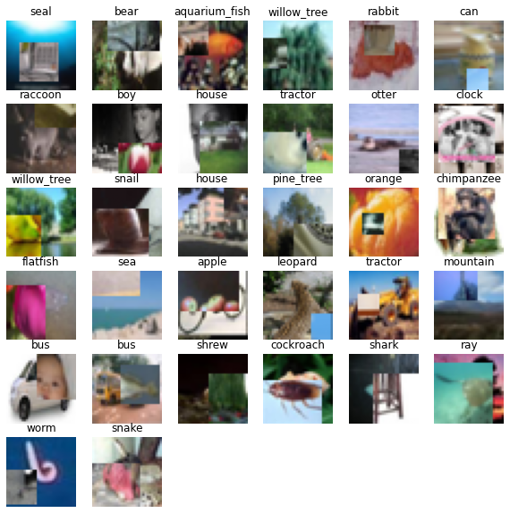

```python
plt.figure(figsize=(10, 10))
for images, labels in train_cm_ds.take(1):
    for i in range(32):
        ax = plt.subplot(6, 6, i + 1)
        plt.imshow(images[i])
        plt.title(LABELS[np.argmax([labels[i]])])
        plt.axis("off")
```

```python
p_net = PyramidNet(alpha = 84, N = 164, block=BottleNeckBlock)

inp = Input(shape=(32, 32, 3))
pyramid_sd_cm = Model(inputs=[inp], outputs=p_net.call(inp), name="BottleNeck_PyramidNet_84_164_ShakeDrop_Cutmix")
```

```python
current_time = datetime.datetime.now(pytz.timezone("Singapore")).strftime("%d:%m:%Y_%H:%M")
pyramid_improvement_run = wandb.init(
    project="CIFAR-100 Image classification",
    name=f"BottleNeck-Pyramid-ShakeDrop-Cutmix{[current_time]}",
    group="BottleNeck-Pyramid-ShakeDrop-Cutmix",
    dir=os.getcwd()
)
```

wandb version 0.13.5 is available! To upgrade, please run: $ pip install wandb --upgrade

Tracking run with wandb version 0.13.4

Run data is saved locally in `c:\Users\limhu\Desktop\DELE\CIFAR100\wandb\run-20221122_100135-2k3gr0rn`

Syncing run **[BottleNeck-Pyramid-ShakeDrop-Cutmix['22:11:2022_10:01']](https://wandb.ai/lhurr/CIFAR-100%20Image%20classification/runs/2k3gr0rn)** to [Weights & Biases](https://wandb.ai/lhurr/CIFAR-100%20Image%20classification) ([docs](https://wandb.me/run))

```
Epoch 24: ReduceLROnPlateau reducing learning rate to 0.175.
Epoch 44: ReduceLROnPlateau reducing learning rate to 0.06124999895691871.
Epoch 58: ReduceLROnPlateau reducing learning rate to 0.021437499113380908.
Epoch 71: ReduceLROnPlateau reducing learning rate to 0.007503124885261058.
```

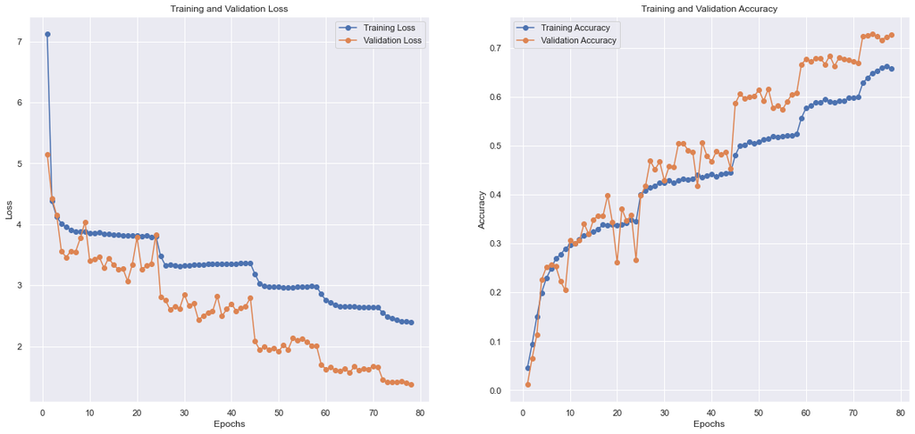

```python
_ = eval_history.evaluate_model(pyramid_sd_cm,train_cm_ds, BATCHSIZE,val_ds=val_ds,
compile_config = COMPILE_CONFIG,wandb_run=pyramid_improvement_run, epochs=EPOCHS,
additional_cb= [
WandbCallback(monitor="val_categorical_accuracy",save_model=True, save_weights_only=False),
EarlyStopping(monitor='val_categorical_accuracy',
                                patience=20,
                                verbose=1,restore_best_weights=True)],
augmentation=True)
```

```python
eval_history.get_history('BottleNeck').iloc[1:]
```

|  | Model Name | Epoch | Model Weights/Model | Train Loss | Val Loss | Train Accuracy | Val Accuracy | Training Log Info |
| --- | --- | --- | --- | --- | --- | --- | --- | --- |
| 0 | BottleNeck_PyramidNet | 55 | C:\Users\limhu\Desktop\DELE\CIFAR100\wandb\run... | 0.2519 | 1.737 | 0.9997 | 0.6539 | C:\Users\limhu\Desktop\DELE\CIFAR100\wandb\run... |
| 0 | BottleNeck_PyramidNet_84_164_ShakeDrop_Cutmix | 78 | C:\Users\limhu\Desktop\DELE\CIFAR100\wandb\run... | 2.4000 | 1.374 | 0.6583 | 0.7264 | C:\Users\limhu\Desktop\DELE\CIFAR100\wandb\run... |

# Further model improvement

1. I noticed earlier that the model is still underfitting, where the validation accuracy is poor and is not able to soar above 75%.
2. To try to further improve the model, we will try out pyramid net-236 and increase the alpha to 220.
3. Hopefully, this will reduce the bias of the model.

```python
p_net = PyramidNet(alpha = 220, N = 236, block=BottleNeckBlock)
inp = Input(shape=(32, 32, 3))
pyramid_220_236 = Model(inputs=[inp], outputs=p_net.call(inp), name="BottleNeck-PyramidNet220-236-ShakeDrop-Cutmix")
```

```python
current_time = datetime.datetime.now(pytz.timezone("Singapore")).strftime("%d:%m:%Y_%H:%M")
pyramid_shakedrop_improvement = wandb.init(
    project="CIFAR-100 Image classification",
    name=f"BottleNeck-Pyramid-ShakeDrop-Cutmix-220-236{[current_time]}",
    group="BottleNeck-Pyramid-ShakeDrop-Cutmix-220-236",
    dir=os.getcwd()
)
```

```
Epoch 20: ReduceLROnPlateau reducing learning rate to 0.175.
Epoch 33: ReduceLROnPlateau reducing learning rate to 0.06124999895691871.
Epoch 40: ReduceLROnPlateau reducing learning rate to 0.021437499113380908.
Epoch 47: ReduceLROnPlateau reducing learning rate to 0.007503124885261058.
Epoch 61: ReduceLROnPlateau reducing learning rate to 0.0026260937098413705.
Epoch 74: ReduceLROnPlateau reducing learning rate to 0.0009191328310407698.
Epoch 96: ReduceLROnPlateau reducing learning rate to 0.00032169649493880566.
```

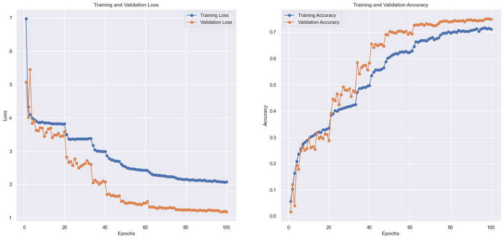

```python
pyramid_sd_results = eval_history.evaluate_model(pyramid_220_236,train_cm_ds, BATCHSIZE,val_ds=val_ds,
compile_config = COMPILE_CONFIG,wandb_run=None, epochs=EPOCHS,
additional_cb= [
# WandbCallback(monitor="val_categorical_accuracy",save_model=True, save_weights_only=False),
EarlyStopping(monitor='val_categorical_accuracy',
                                patience=30,
                                verbose=1,restore_best_weights=True)],
augmentation=True)
```

- Although we have managed to lower the bias, our model is generally still underfitting.
- Despite making the model more complex, our model with shakedrop and cutmix augmentation is still not performing very well and is not able to surpass 80% validation and train accuracy.
- Overall, pyramidnet with shakedrop and cutmix augmentation is our best model so far with low variance, but with subpar validation accuracy of 75%

```python
eval_history.get_history('BottleNeck')
```

|  | Model Name | Epoch | Model Weights/Model | Train Loss | Val Loss | Train Accuracy | Val Accuracy | Training Log Info |
| --- | --- | --- | --- | --- | --- | --- | --- | --- |
| 0 | BottleNeck-PyramidNet220-236-ShakeDrop-Cutmix | 100 | C:\Users\limhu\Desktop\DELE\CIFAR100\wandb\run... | 2.0729 | 1.1967 | 0.7159 | 0.7511 | C:\Users\limhu\Desktop\DELE\CIFAR100\wandb\run... |
| 0 | BottleNeck_PyramidNet | 55 | C:\Users\limhu\Desktop\DELE\CIFAR100\wandb\run... | 0.2519 | 1.7370 | 0.9997 | 0.6539 | C:\Users\limhu\Desktop\DELE\CIFAR100\wandb\run... |
| 0 | BottleNeck_PyramidNet_84_164_ShakeDrop_Cutmix | 78 | C:\Users\limhu\Desktop\DELE\CIFAR100\wandb\run... | 2.4000 | 1.3740 | 0.6583 | 0.7264 | C:\Users\limhu\Desktop\DELE\CIFAR100\wandb\run... |

#### Classification report and confusion matrix for normal pyramid net with bottleneck block

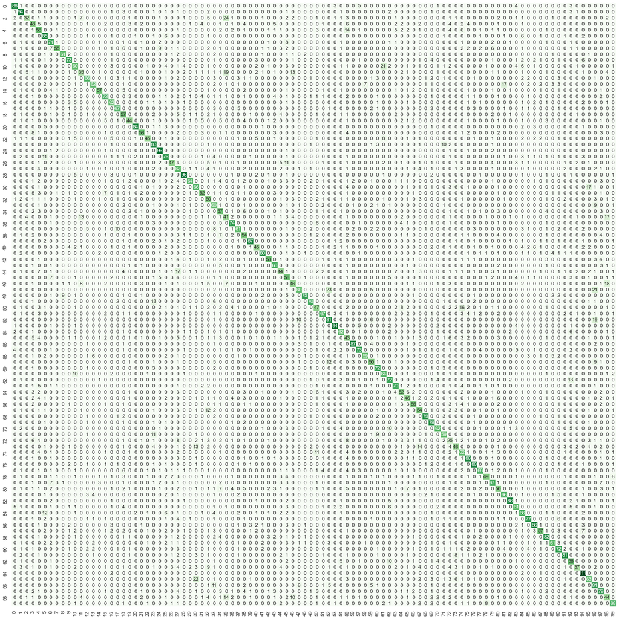

```python
basic_bottleneck = eval_history.get_model('BottleNeck_PyramidNet', pyramid_bottleneck)
improved_bottleneck = eval_history.get_model('BottleNeck-PyramidNet220-236-ShakeDrop-Cutmix', pyramid_220_236)
models = [basic_bottleneck, improved_bottleneck]
plt.figure(figsize=(20,20))
y_val_pred1 = models[0].predict(X_val)
cm = confusion_matrix(y_val.argmax(axis=1), y_val_pred1.argmax(axis=1))
sns.heatmap(cm, annot=True, fmt='g', cbar=False, cmap='Greens')
plt.tight_layout()
```

```python
display(pd.DataFrame(classification_report(y_val.argmax(axis=1), y_val_pred1.argmax(axis=1), target_names=LABELS.values(), output_dict=True)).T.sort_values('f1-score'))
```

|  | precision | recall | f1-score | support |
| --- | --- | --- | --- | --- |
| seal | 0.284091 | 0.284091 | 0.284091 | 88.0 |
| otter | 0.318519 | 0.413462 | 0.359833 | 104.0 |
| girl | 0.372727 | 0.414141 | 0.392344 | 99.0 |
| boy | 0.507246 | 0.343137 | 0.409357 | 102.0 |
| crocodile | 0.344444 | 0.607843 | 0.439716 | 102.0 |
| ... | ... | ... | ... | ... |
| orange | 0.854545 | 0.846847 | 0.850679 | 111.0 |
| sunflower | 0.886598 | 0.819048 | 0.851485 | 105.0 |
| chair | 0.923077 | 0.823529 | 0.870466 | 102.0 |
| road | 0.918605 | 0.840426 | 0.877778 | 94.0 |
| palm_tree | 0.915789 | 0.852941 | 0.883249 | 102.0 |

103 rows × 4 columns

- We can see from the classification report, our normal pyramid net model is able to classify nature images like tree/sunflower well, but however, performs poorly on animals, and humans. For example the model performs badly for seal and otter. This might be due to the fact that they both have the same silhouette and shape

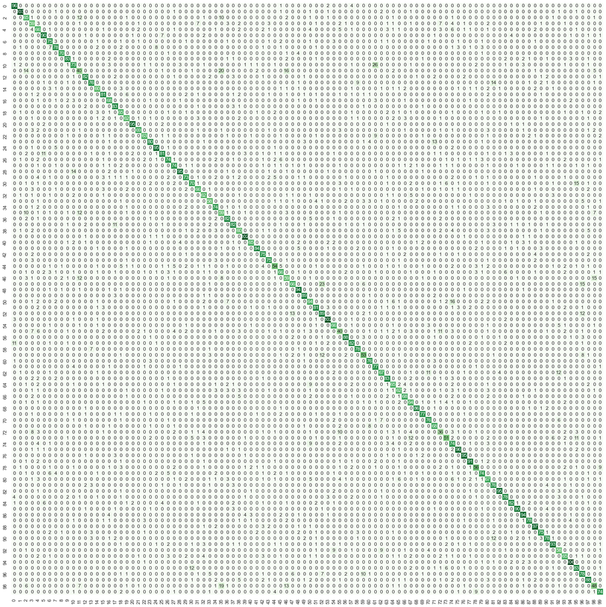

```python
plt.figure(figsize=(20,20))
y_val_pred2 = models[1].predict(X_val)

cm = confusion_matrix(y_val.argmax(axis=1), y_val_pred2.argmax(axis=1))
sns.heatmap(cm, annot=True, fmt='g', cbar=False, cmap='Greens')
plt.tight_layout()
```

```python
display(pd.DataFrame(classification_report(y_val.argmax(axis=1), y_val_pred2.argmax(axis=1), target_names=LABELS.values(), output_dict=True)).T.sort_values('f1-score'))
```

|  | precision | recall | f1-score | support |
| --- | --- | --- | --- | --- |
| boy | 0.454545 | 0.392157 | 0.421053 | 102.0 |
| otter | 0.493827 | 0.384615 | 0.432432 | 104.0 |
| seal | 0.461538 | 0.409091 | 0.433735 | 88.0 |
| woman | 0.578313 | 0.470588 | 0.518919 | 102.0 |
| girl | 0.500000 | 0.595960 | 0.543779 | 99.0 |
| ... | ... | ... | ... | ... |
| sunflower | 0.922330 | 0.904762 | 0.913462 | 105.0 |
| aquarium_fish | 0.919643 | 0.911504 | 0.915556 | 113.0 |
| road | 0.924731 | 0.914894 | 0.919786 | 94.0 |
| bicycle | 0.933333 | 0.909091 | 0.921053 | 77.0 |
| chair | 0.931373 | 0.931373 | 0.931373 | 102.0 |

103 rows × 4 columns

```python
!jupyter nbconvert --to html 2_PyramidNet.ipynb
```